# R_spark

## [Spark with R](https://therinspark.com)

## Introduction

**Apache Spark as a leading tool that is democratizing our ability to process large datasets.** With this as a backdrop, we introduce the R computing language, which was specifically designed to simplify data analysis. Finally, this leads us to introduce **sparklyr, a project merging R and Spark into a powerful tool that is easily accessible to all.**

### **Hadoop**

Search engines like Google were unable to store all of the web page information required to support web searches in a single computer. This meant that they had to split information into several files and store them across many machines. This approach became known as the Google File System, and was presented in a research paper published in 2003 by Google.

One year later, Google published a new paper describing how to perform operations across the Google File System, an approach that came to be known as MapReduce.

There are two operations in MapReduce: map and reduce. The map operation provides an arbitrary way to transform each file into a new file, whereas the reduce operation combines two files. Both operations require custom computer code, but the **MapReduce framework takes care of automatically executing them across many computers at once.** These two operations are sufficient to process all the data available on the web, while also providing enough flexibility to extract meaningful information from it.

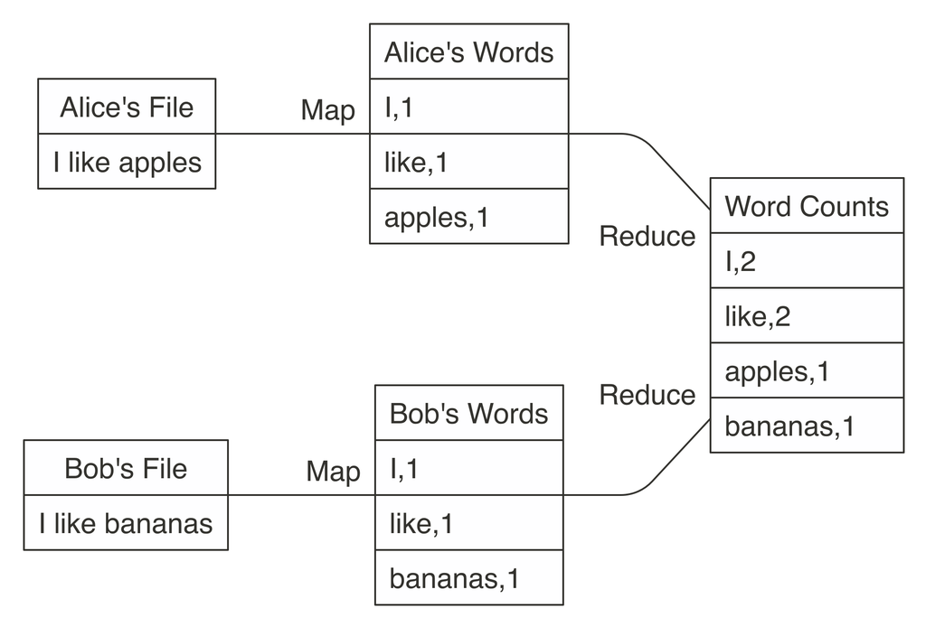

Counting words is often the most basic MapReduce example, but we can also use MapReduce for much more sophisticated and interesting applications.

After these papers were released by Google, a team at Yahoo worked on implementing the Google File System and MapReduce as a single open source project. This project was released in 2006 as Hadoop, with the Google File System implemented as the Hadoop Distributed File System (HDFS). **The Hadoop project made distributed file-based computing accessible to a wider range of users and organizations, making MapReduce useful beyond web data processing.**

Although Hadoop provided support to perform MapReduce operations over a distributed file system, it still required MapReduce operations to be written with code every time a data analysis was run. To improve upon this tedious process, the Hive project, released in 2008 by Facebook, brought Structured Query Language (SQL) support to Hadoop. This meant that data analysis could now be performed at large scale without the need to write code for each MapReduce operation; instead, one could write generic data analysis statements in SQL, which are much easier to understand and write.

### **Spark**

In 2009, Apache Spark began as a research project at UC Berkeley’s AMPLab to improve on MapReduce. Specifically, Spark provided a richer set of verbs beyond MapReduce to facilitate optimizing code running in multiple machines. Spark also loaded data in-memory, making operations much faster than Hadoop’s on-disk storage.

Spark is also easier to use than Hadoop; for instance, the word-counting MapReduce example takes about 50 lines of code in Hadoop, but it takes only 2 lines of code in Spark. As you can see, Spark is much faster, more efficient, and easier to use than Hadoop.

**Describing Spark as large scale implies that a good use case for Spark is tackling problems that can be solved with multiple machines. For instance, when data does not fit on a single disk drive or into memory, Spark is a good candidate to consider.**

Therefore, Spark is good at tackling large-scale data-processing problems, usually known as big data (datasets that are more voluminous and complex than traditional ones) **but it is also good at tackling large-scale computation problems, known as big compute** (tools and approaches using a large amount of CPU and memory resources in a coordinated way).

### **Big Data**

**When working in Data Science or Machine Learning, you will be faced with increasingly large datasets or increasingly complex computations that are slow to execute or at times even impossible to process in a single computer**. However, it is important to understand that Spark does not need to be the answer to all our computations problems; instead, when faced with computing challenges in R, using the following techniques can be as effective:

- **Sampling** A first approach to try is to reduce the amount of data being handled, through sampling. However, we must sample the data properly by applying sound statistical principles. For instance, selecting the top results is not sufficient in sorted datasets; with simple random sampling, there might be underrepresented groups, which we could overcome with stratified sampling, which in turn adds complexity to properly select categories.
- **Profiling** You can try to understand why a computation is slow and make the necessary improvements. A profiler is a tool capable of inspecting code execution to help identify bottlenecks. It’s not always trivial to optimize.
- **Scaling Up** **Speeding up computation is usually possible by buying faster or more capable hardware (say, increasing your machine memory, upgrading your hard drive, or procuring a machine with many more CPUs); this approach is known as scaling up.** However, there are usually hard limits as to how much a single computer can scale up, and even with significant CPUs, you need to find frameworks that parallelize computation efficiently.
- **Scaling Out** Finally, we can consider **spreading computation and storage across multiple machines. This approach provides the highest degree of scalability because you can potentially use an arbitrary number of machines to perform a computation.** This approach is commonly known as scaling out. However, spreading computation effectively across many machines is a complex endeavor, especially without using specialized tools and frameworks like Apache Spark.

### [sparklyr](https://spark.rstudio.com/dplyr/)

**sparklyr is an R interface for Apache Spark.** It’s available in CRAN and works like any other CRAN package.

Spark as a modern and powerful computing platform, R as an easy-to-use computing language with solid foundations in statistical methods, and sparklyr as a project bridging both technologies and communities. In a world in which the total amount of information is growing exponentially, learning how to analyze data at scale will help you to tackle the problems and opportunities humanity is facing today.

From R, getting started with Spark using sparklyr and a local cluster is as easy as installing and loading the sparklyr package followed by installing Spark using sparklyr. For instance, Databricks hosts a free community edition of Spark that you can easily access from your web browser.

After you are done with the prerequisites, you will first learn how to connect to Spark. We then present the most important tools and operations that you’ll use throughout the rest of this book.

All Spark operations are run from R; however, monitoring execution of distributed operations is performed from Spark’s web interface, which you can load from any web browser. We then disconnect from this local cluster, which is easy to forget to do but highly recommended while working with local clusters—and in shared Spark clusters as well!

Because Spark is built in the Scala programming language, which is run by the Java Virtual Machine (JVM), you also need to install Java 8 on your system.

```r
#install.packages("sparklyr")
#packageVersion("sparklyr")

library(sparklyr)
spark_install("2.3")
```

So far, **we’ve installed only a local Spark cluster. A local cluster is really helpful to get started, test code, and troubleshoot with ease.** Later chapters explain where to find, install, and connect to real Spark clusters with many machines, but for the first few chapters, we focus on using local clusters.

```r
library(sparklyr)
sc <- spark_connect(master = "local", version = "2.3")
```

**The master parameter identifies which is the “main” machine from the Spark cluster; this machine is often called the driver node. While working with real clusters using many machines, you’ll find that most machines will be worker machines and one will be the master.** Since we have only a local cluster with just one machine, we will default to using “local” for now.

After a connection is established, spark_connect() retrieves an active Spark connection, which most code usually names sc; you will then make use of sc to execute Spark commands.

```r
cars <- copy_to(sc, mtcars)
cars
```

```
## # Source: spark<mtcars> [?? x 11]
##      mpg   cyl  disp    hp  drat    wt  qsec    vs    am  gear  carb
##    <dbl> <dbl> <dbl> <dbl> <dbl> <dbl> <dbl> <dbl> <dbl> <dbl> <dbl>
##  1  21       6  160    110  3.9   2.62  16.5     0     1     4     4
##  2  21       6  160    110  3.9   2.88  17.0     0     1     4     4
##  3  22.8     4  108     93  3.85  2.32  18.6     1     1     4     1
##  4  21.4     6  258    110  3.08  3.22  19.4     1     0     3     1
##  5  18.7     8  360    175  3.15  3.44  17.0     0     0     3     2
##  6  18.1     6  225    105  2.76  3.46  20.2     1     0     3     1
##  7  14.3     8  360    245  3.21  3.57  15.8     0     0     3     4
##  8  24.4     4  147.    62  3.69  3.19  20       1     0     4     2
##  9  22.8     4  141.    95  3.92  3.15  22.9     1     0     4     2
## 10  19.2     6  168.   123  3.92  3.44  18.3     1     0     4     4
## # ... with more rows
```

## Spark web interface

**Most of the Spark commands are executed from the R console; however, monitoring and analyzing execution is done through Spark’s web interface.**

```r
spark_web(sc)
```

[figure not shown]

Printing the cars dataset collected a few records to be displayed in the R console. You can see in the Spark web interface that a job was started to collect this information back from Spark.

[figure not shown]

The Executors tab provides a view of your cluster resources. For local connections, you will find only one executor active with only 2 GB of memory allocated to Spark, and 384 MB available for computation.

[figure not shown]

## Analysis

When using Spark from R to analyze data, you can use SQL (Structured Query Language) or dplyr (a grammar of data manipulation). You can use SQL through the DBI package; for instance, to count how many records are available in our cars dataset, we can run the following:

```r
library(DBI)
dbGetQuery(sc, "SELECT count(*) FROM mtcars")
```

```
##   count(1)
## 1       32
```

When using dplyr, you write less code, and it’s often much easier to write than SQL.

```r
library(dplyr)
print(count(cars))
```

```
## # Source: spark<?> [?? x 1]
##       n
##   <dbl>
## 1    32
```

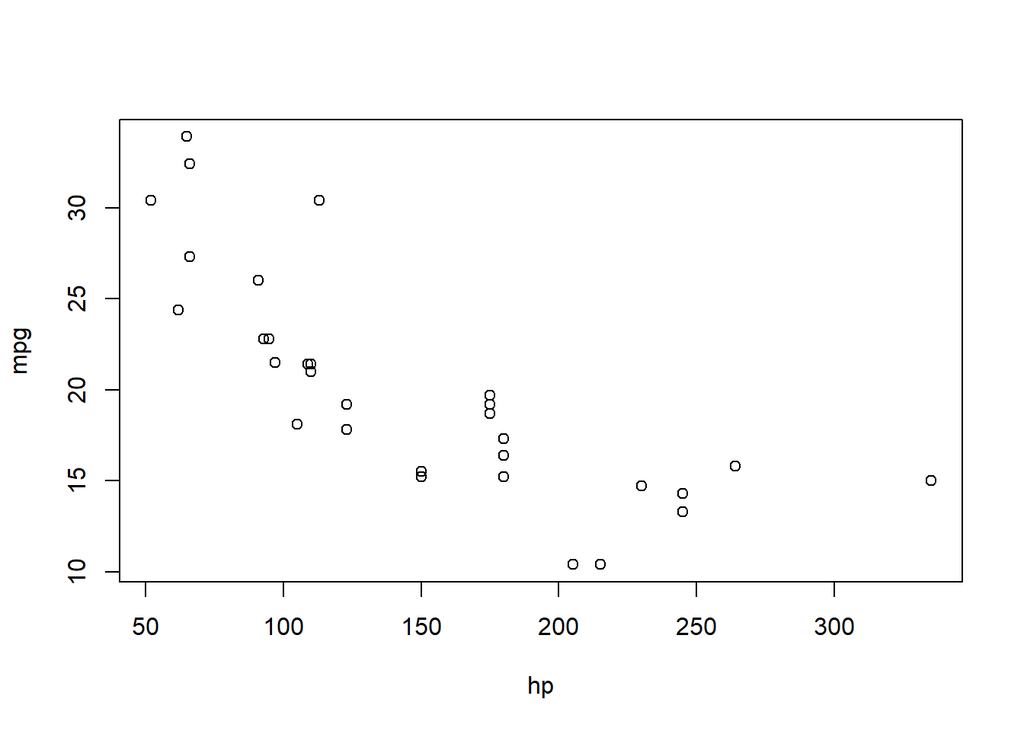

```r
select(cars, hp, mpg) %>%
  sample_n(100) %>%
  collect() %>%
  plot()
```

## Modelling

We can use a linear model to approximate the relationship between fuel efficiency and horsepower:

```r
model <- ml_linear_regression(cars, mpg ~ hp)
model
```

```
## Formula: mpg ~ hp
##
## Coefficients:
## (Intercept)          hp
## 30.09886054 -0.06822828
```

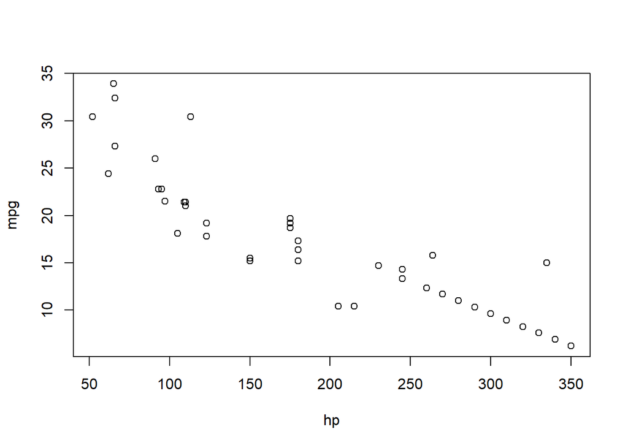

```r
model %>%
  ml_predict(copy_to(sc, data.frame(hp = 250 + 10 * 1:10))) %>%
  transmute(hp = hp, mpg = prediction) %>%
  full_join(select(cars, hp, mpg)) %>%
  collect() %>%
  plot()
```

## Data

For simplicity, we copied the mtcars dataset into Spark; however, **data is usually not copied into Spark. Instead, data is read from existing data sources in a variety of formats, like plain text, CSV, JSON, Java Database Connectivity (JDBC).**

```r
#spark_write_csv(cars, "cars.csv")
cars <- spark_read_csv(sc, "cars.csv")
```

## Extensions

The sparkly.nested extension is an R package that extends sparklyr to help you manage values that contain nested information. A common use case involves JSON files that contain nested lists that require preprocessing before you can do meaningful data analysis.

```r
sparklyr.nested::sdf_nest(cars, hp) %>%
  group_by(cyl) %>%
  summarise(data = collect_list(data))
```

```
## # Source: spark<?> [?? x 2]
##     cyl data
##   <dbl> <list>
## 1     6 <list [7]>
## 2     4 <list [11]>
## 3     8 <list [14]>
```

## Distributed R

**For those few cases when a particular functionality is not available in Spark and no extension has been developed, you can consider distributing your own R code across the Spark cluster.** This is a powerful tool, but it comes with additional complexity, so you should only use it as a last resort.

Suppose that we need to round all of the values across all the columns in our dataset. One approach would be running custom R code, making use of R’s round() function:

```r
cars %>% spark_apply(~round(.x))
```

```
## # Source: spark<?> [?? x 11]
##      mpg   cyl  disp    hp  drat    wt  qsec    vs    am  gear  carb
##    <dbl> <dbl> <dbl> <dbl> <dbl> <dbl> <dbl> <dbl> <dbl> <dbl> <dbl>
##  1    21     6   160   110     4     3    16     0     1     4     4
##  2    21     6   160   110     4     3    17     0     1     4     4
##  3    23     4   108    93     4     2    19     1     1     4     1
##  4    21     6   258   110     3     3    19     1     0     3     1
##  5    19     8   360   175     3     3    17     0     0     3     2
##  6    18     6   225   105     3     3    20     1     0     3     1
##  7    14     8   360   245     3     4    16     0     0     3     4
##  8    24     4   147    62     4     3    20     1     0     4     2
##  9    23     4   141    95     4     3    23     1     0     4     2
## 10    19     6   168   123     4     3    18     1     0     4     4
## # ... with more rows
```

**If you are a proficient R user, it can be quite tempting to use spark_apply() for everything, but please, don’t! spark_apply() was designed for advanced use cases where Spark falls short.**

### Logs

Logging is definitely less interesting than real-time data processing; however, it’s a tool you should be or become familiar with. A log is just a text file to which Spark appends information relevant to the execution of tasks in the cluster. For local clusters, we can retrieve all the recent logs by running the following:

```r
spark_log(sc)
```

[output not shown]

[output cut: 45 more lines]

```
## 21/12/20 16:28:32 INFO MemoryStore: Block broadcast_55_piece0 stored as bytes in memory (estimated size 24.3 KB, free 911.6 MB)
## 21/12/20 16:28:32 INFO BlockManagerInfo: Added broadcast_55_piece0 in memory on kubernetes.docker.internal:55178 (size: 24.3 KB, free: 912.2 MB)
## 21/12/20 16:28:32 INFO SparkContext: Created broadcast 55 from broadcast at DAGScheduler.scala:1039
## 21/12/20 16:28:32 INFO DAGScheduler: Submitting 1 missing tasks from ResultStage 42 (MapPartitionsRDD[186] at collect at utils.scala:24) (first 15 tasks are for partitions Vector(0))
## 21/12/20 16:28:32 INFO TaskSchedulerImpl: Adding task set 42.0 with 1 tasks
## 21/12/20 16:28:32 INFO TaskSetManager: Starting task 0.0 in stage 42.0 (TID 63, localhost, executor driver, partition 0, PROCESS_LOCAL, 8382 bytes)
## 21/12/20 16:28:32 INFO Executor: Running task 0.0 in stage 42.0 (TID 63)
## 21/12/20 16:28:32 INFO BlockManager: Found block rdd_174_0 locally
## 21/12/20 16:28:32 INFO Executor: 1 block locks were not released by TID = 63:
## [rdd_174_0]
## 21/12/20 16:28:32 INFO Executor: Finished task 0.0 in stage 42.0 (TID 63). 2103 bytes result sent to driver
## 21/12/20 16:28:32 INFO TaskSetManager: Finished task 0.0 in stage 42.0 (TID 63) in 5 ms on localhost (executor driver) (1/1)
## 21/12/20 16:28:32 INFO TaskSchedulerImpl: Removed TaskSet 42.0, whose tasks have all completed, from pool
## 21/12/20 16:28:32 INFO DAGScheduler: ResultStage 42 (collect at utils.scala:24) finished in 0.012 s
## 21/12/20 16:28:32 INFO DAGScheduler: Job 31 finished: collect at utils.scala:24, took 0.015626 s
```

```r
spark_log(sc, filter = "sparklyr")
```

[output not shown]

[output cut: 74 more lines]

### Disconnecting

For local clusters (really, any cluster), after you are done processing data, you should disconnect by running the following:

```r
spark_disconnect(sc)
```

This terminates the connection to the cluster as well as the cluster tasks. If multiple Spark connections are active, or if the connection instance sc is no longer available, you can also disconnect all your Spark connections by running this command:

```r
spark_disconnect_all()
```

```
## [1] 0
```

## Analysis

In a data analysis project, the main goal is to understand what the data is trying to “tell us”, hoping that it provides an answer to a specific question.

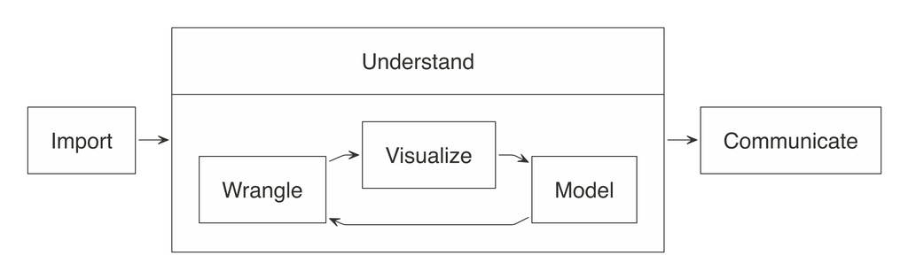

As the diagram illustrates, we first import data into our analysis stem, where we wrangle it by trying different data transformations, such as aggregations. We then visualize the data to help us perceive relationships and trends. To gain deeper insight, we can fit one or multiple statistical models against sample data. This will help us find out whether the patterns hold true when new data is applied to them. Lastly, the results are communicated publicly or privately to colleagues and stakeholders.

When working with not-large-scale datasets—as in datasets that fit in memory—we can perform all those steps from R, without using Spark. However, when data does not fit in memory or computation is simply too slow, we can slightly modify this approach by incorporating Spark. But how?

For data analysis, **the ideal approach is to let Spark do what it’s good at. Spark is a(((“parallel execution”))) parallel computation engine that works at a large scale and provides a SQL engine and modeling libraries.**

For example, when you need to fit a linear regression model, instead of using R’s familiar lm() function, you would use Spark’s ml_linear_regression() function. This R function then calls Spark to create this model.

**For more common data manipulation tasks, sparklyr provides a backend for dplyr. This means you can use dplyr verbs with which you’re already familiar in R, and then sparklyr and dplyr will translate those actions into Spark SQL statements, which are generally more compact and easier to read than SQL statements.**

```r
library(sparklyr)
library(dplyr)

sc <- spark_connect(master = "local", version = "2.3")
```

## Import

When using Spark with R, you need to approach importing data differently. Usually, importing means that R will read files and load them into memory; when you are using Spark, the data is imported into Spark, not R.

Note: When you’re performing analysis over large-scale datasets, the vast majority of the necessary data will already be available in your Spark cluster (which is usually made available to users via Hive tables or by accessing the file system directly).

**Rather than importing all data into Spark, you can request Spark to access the data source without importing it** — this is a decision you should make based on speed and performance. **Importing all of the data into the Spark session incurs a one-time up-front cost, since Spark needs to wait for the data to be loaded before analyzing it.** If the data is not imported, you usually incur a cost with every Spark operation since Spark needs to retrieve a subset from the cluster’s storage, which is usually disk drives that happen to be much slower than reading from Spark’s memory.

```r
cars <- copy_to(sc, mtcars)
```

Note: **When using real clusters, you should use copy_to() to transfer only small tables from R; large data transfers should be performed with specialized data transfer tools.**

## Wrangle

Data wrangling uses transformations to understand the data. It is often referred to as the process of transforming data from one “raw” data form into another format with the intent of making it more appropriate for data analysis.

Malformed or missing values and columns with multiple attributes are common data problems you might need to fix, since they prevent you from understanding your dataset. For example, a “name” field contains the last and first name of a customer. There are two attributes (first and last name) in a single column. To be usable, we need to transform the “name” field, by changing it into “first_name” and “last_name” fields.

The main goal is to write the data transformations using R syntax as much as possible.

```r
summarize_all(cars, mean)
```

```
## # Source: spark<?> [?? x 11]
##     mpg   cyl  disp    hp  drat    wt  qsec    vs    am  gear  carb
##   <dbl> <dbl> <dbl> <dbl> <dbl> <dbl> <dbl> <dbl> <dbl> <dbl> <dbl>
## 1  20.1  6.19  231.  147.  3.60  3.22  17.8 0.438 0.406  3.69  2.81
```

While this code is exactly the same as the code you would run when using dplyr without Spark, a lot is happening under the hood. The data is not being imported into R; instead, dplyr converts this task into SQL statements that are then sent to Spark. **The show_query() command makes it possible to peer into the SQL statement that sparklyr and dplyr created and sent to Spark.**

```r
summarize_all(cars, mean) %>%
  show_query()
```

```
## <SQL>
## SELECT AVG(`mpg`) AS `mpg`, AVG(`cyl`) AS `cyl`, AVG(`disp`) AS `disp`, AVG(`hp`) AS `hp`, AVG(`drat`) AS `drat`, AVG(`wt`) AS `wt`, AVG(`qsec`) AS `qsec`, AVG(`vs`) AS `vs`, AVG(`am`) AS `am`, AVG(`gear`) AS `gear`, AVG(`carb`) AS `carb`
## FROM `mtcars`
```

```r
cars %>%
  mutate(transmission = ifelse(am == 0, "automatic", "manual")) %>%
  group_by(transmission) %>%
  summarise_all(mean)
```

```
## # Source: spark<?> [?? x 12]
##   transmission   mpg   cyl  disp    hp  drat    wt  qsec    vs    am  gear  carb
##   <chr>        <dbl> <dbl> <dbl> <dbl> <dbl> <dbl> <dbl> <dbl> <dbl> <dbl> <dbl>
## 1 automatic     17.1  6.95  290.  160.  3.29  3.77  18.2 0.368     0  3.21  2.74
## 2 manual        24.4  5.08  144.  127.  4.05  2.41  17.4 0.538     1  4.38  2.92
```

### Built-in functions

**Spark SQL is based on Hive’s SQL conventions and functions, and it is possible to call all these functions using dplyr as well. This means that we can use any Spark SQL functions to accomplish operations that might not be available via dplyr.** We can access the functions by calling them as if they were R functions.

```r
summarise(cars, mpg_percentile = percentile(mpg, 0.25))
```

```
## # Source: spark<?> [?? x 1]
##   mpg_percentile
##            <dbl>
## 1           15.4
```

There is no percentile() function in R, so dplyr passes that portion of the code as-is to the resulting SQL query:

```r
summarise(cars, mpg_percentile = percentile(mpg, 0.25)) %>%
  show_query()
```

```
## <SQL>
## SELECT percentile(`mpg`, 0.25) AS `mpg_percentile`
## FROM `mtcars`
```

To pass multiple values to percentile(), we can call another Hive function called array(). In this case, array() would work similarly to R’s list() function.

```r
summarise(cars, mpg_percentile = percentile(mpg, array(0.25, 0.5, 0.75)))
```

```
## # Source: spark<?> [?? x 1]
##   mpg_percentile
##   <list>
## 1 <dbl [3]>
```

**You can use the explode() function to separate Spark’s array value results into their own record.** To do this, use explode() within a mutate() command, and pass the variable containing the results of the percentile operation:

```r
summarise(cars, mpg_percentile = percentile(mpg, array(0.25, 0.5, 0.75))) %>%
  mutate(mpg_percentile = explode(mpg_percentile))
```

```
## # Source: spark<?> [?? x 1]
##   mpg_percentile
##            <dbl>
## 1           15.4
## 2           19.2
## 3           22.8
```

We have included a comprehensive list of all the Hive functions in the section [Hive Functions](https://therinspark.com/appendix.html#hive-functions). Glance over them to get a sense of the wide range of operations that you can accomplish with them.

### Correlations

A very common exploration technique is to calculate and visualize correlations.

```r
ml_corr(cars)
```

```
## * `` -> ...1
## * `` -> ...2
## * `` -> ...3
## * `` -> ...4
## * `` -> ...5
## * ...
```

```
## # A tibble: 11 x 11
##       mpg    cyl   disp     hp    drat     wt    qsec     vs      am   gear
##     <dbl>  <dbl>  <dbl>  <dbl>   <dbl>  <dbl>   <dbl>  <dbl>   <dbl>  <dbl>
##  1  1     -0.852 -0.848 -0.776  0.681  -0.868  0.419   0.664  0.600   0.480
##  2 -0.852  1      0.902  0.832 -0.700   0.782 -0.591  -0.811 -0.523  -0.493
##  3 -0.848  0.902  1      0.791 -0.710   0.888 -0.434  -0.710 -0.591  -0.556
##  4 -0.776  0.832  0.791  1     -0.449   0.659 -0.708  -0.723 -0.243  -0.126
##  5  0.681 -0.700 -0.710 -0.449  1      -0.712  0.0912  0.440  0.713   0.700
##  6 -0.868  0.782  0.888  0.659 -0.712   1     -0.175  -0.555 -0.692  -0.583
##  7  0.419 -0.591 -0.434 -0.708  0.0912 -0.175  1       0.745 -0.230  -0.213
##  8  0.664 -0.811 -0.710 -0.723  0.440  -0.555  0.745   1      0.168   0.206
##  9  0.600 -0.523 -0.591 -0.243  0.713  -0.692 -0.230   0.168  1       0.794
## 10  0.480 -0.493 -0.556 -0.126  0.700  -0.583 -0.213   0.206  0.794   1
## 11 -0.551  0.527  0.395  0.750 -0.0908  0.428 -0.656  -0.570  0.0575  0.274
## # ... with 1 more variable: carb <dbl>
```

We can pipe the results to other corrr functions. For example, the shave() function turns all of the duplicated results into NAs.

```
## * `` -> ...1
## * `` -> ...2
## * `` -> ...3
## * `` -> ...4
## * `` -> ...5
## * ...
```

```
##
## Correlation method: 'pearson'
## Missing treated using: 'pairwise.complete.obs'
```

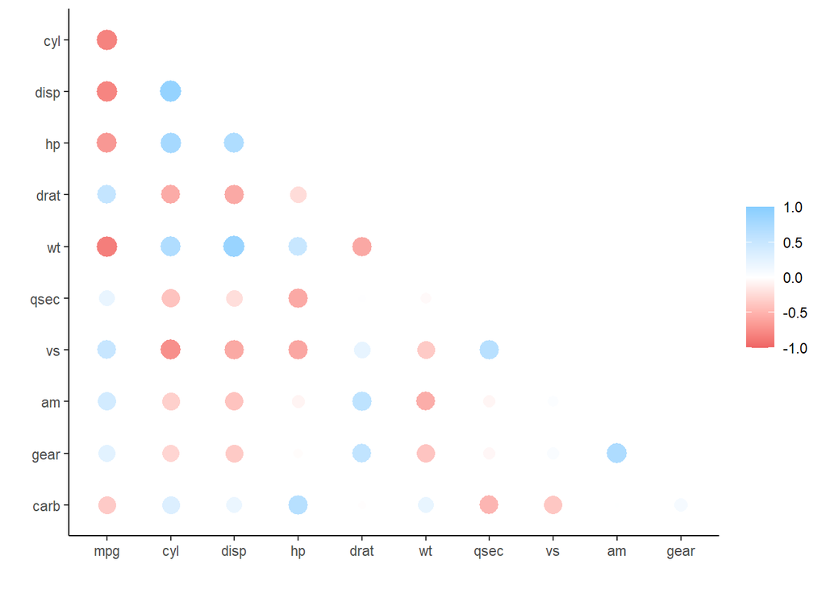

```r
library(corrr)
correlate(cars, use = "pairwise.complete.obs", method = "pearson") %>%
  shave() %>%
  rplot()
```

### Visualize

Visualizations are a vital tool to help us find patterns in the data. It is easier for us to identify outliers in a dataset of 1,000 observations when plotted in a graph, as opposed to reading them from a list.

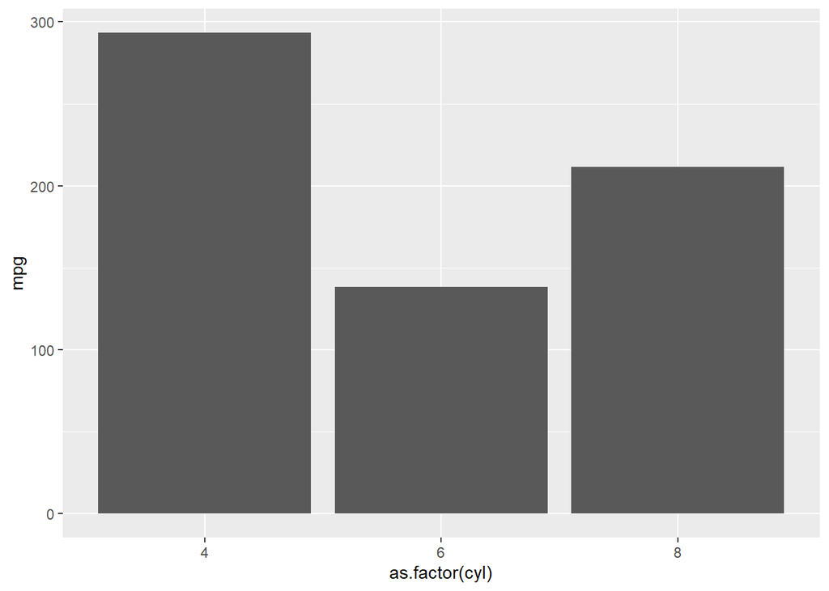

```r
library(ggplot2)

ggplot(aes(as.factor(cyl), mpg), data = mtcars) + geom_col()
```

In Spark, there are a couple of key steps when codifying the **“push compute, collect results” approach.** **First, ensure that the transformation operations happen within Spark. In the example that follows, group_by() and summarise() will run inside Spark. The second is to bring the results back into R after the data has been transformed. Be sure to transform and then collect, in that order; if collect() is run first, R will try to ingest the entire dataset from Spark. Depending on the size of the data, collecting all of the data will slow down or can even bring down your system.**

```r
car_group <- cars %>%
  group_by(cyl) %>%
  summarise(mpg = sum(mpg, na.rm = TRUE)) %>%
  collect() %>%
  print()
```

```
## # A tibble: 3 x 2
##     cyl   mpg
##   <dbl> <dbl>
## 1     6  138.
## 2     4  293.
## 3     8  211.
```

The approach, then, is to **push as much compute to the cluster as possible**, using R primarily as an interface to Spark for the Data Scientist, which will then **collect as few results as possible** back into R memory, mostly to visualize and communicate. As shown in the slide, the more import, tidy, transform and modeling work we can push to Spark, the faster we can analyze very large data sets.

[figure not shown]

#### Using [dbplot](https://edgararuiz.github.io/dbplot/)

**The dbplot package provides helper functions for plotting with remote data. The R code dbplot that’s used to transform the data is written so that it can be translated into Spark.**

The dbplot_histogram() function makes Spark calculate the bins and the count per bin and outputs a ggplot object, which we can further refine by adding more steps to the plot object. dbplot_histogram() also accepts a binwidth argument to control the range used to compute the bins:

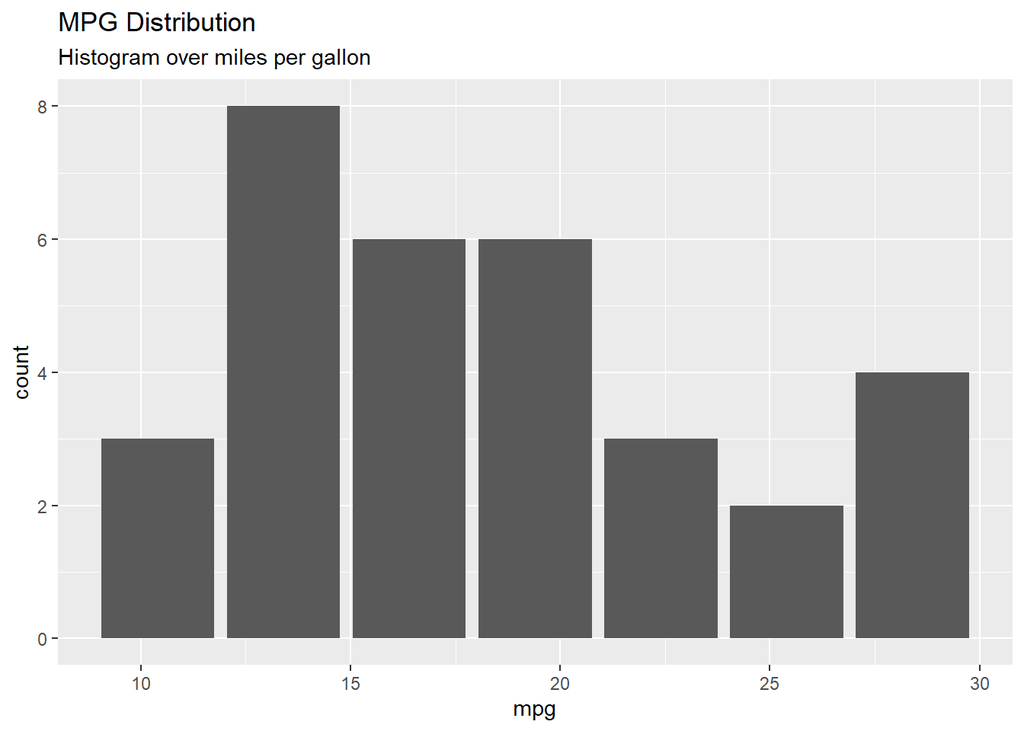

```r
library(dbplot)

cars %>%
dbplot_histogram(mpg, binwidth = 3) +
labs(title = "MPG Distribution",
     subtitle = "Histogram over miles per gallon")
```

A raster plot returns a grid of x/y positions and the results of a given aggregation, usually represented by the color of the square.

Raster: To visualize two continuous variables, we typically resort to a Scatter plot. However, this may not be practical when visualizing millions or billions of dots representing the intersections of the two variables. A Raster plot may be a better option, because it concentrates the intersections into squares that are easier to parse visually.

A Raster plot basically does the same as a Histogram. It takes two continuous variables and creates discrete 2-dimensional bins represented as squares in the plot. It then determines either the number of rows inside each square or processes some aggregation, like an average.

You can use dbplot_raster() to create a scatter-like plot in Spark, while only retrieving (collecting) a small subset of the remote dataset:

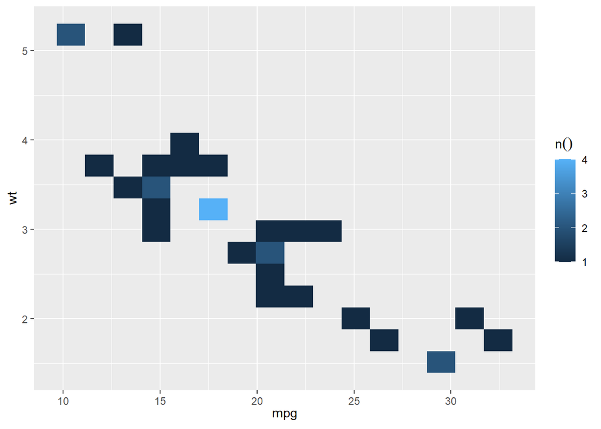

```r
dbplot_raster(cars, mpg, wt, resolution = 16)
```

## Model

We want to cover how to interact with models while doing data analysis.

```r
cars %>%
  ml_linear_regression(mpg ~ .) %>%
  summary()
```

```
## Deviance Residuals:
##     Min      1Q  Median      3Q     Max
## -3.4506 -1.6044 -0.1196  1.2193  4.6271
##
## Coefficients:
## (Intercept)         cyl        disp          hp        drat          wt
## 12.30337416 -0.11144048  0.01333524 -0.02148212  0.78711097 -3.71530393
##        qsec          vs          am        gear        carb
##  0.82104075  0.31776281  2.52022689  0.65541302 -0.19941925
##
## R-Squared: 0.869
## Root Mean Squared Error: 2.147
```

At this point, it is very easy to experiment with different features, we can simply change the R formula from mpg ~ . to, say, mpg ~ hp + cyl to only use horsepower and cylinders as features:

```r
cars %>%
  ml_linear_regression(mpg ~ hp + cyl) %>%
  summary()
```

```
## Deviance Residuals:
##     Min      1Q  Median      3Q     Max
## -4.4948 -2.4901 -0.1828  1.9777  7.2934
##
## Coefficients:
## (Intercept)          hp         cyl
##  36.9083305  -0.0191217  -2.2646936
##
## R-Squared: 0.7407
## Root Mean Squared Error: 3.021
```

It is also very easy to iterate with other kinds of models. The following one replaces the linear model with a generalized linear model:

```r
cars %>%
  ml_generalized_linear_regression(mpg ~ hp + cyl) %>%
  summary()
```

```
## Deviance Residuals:
##     Min      1Q  Median      3Q     Max
## -4.4948 -2.4901 -0.1828  1.9777  7.2934
##
## Coefficients:
## (Intercept)          hp         cyl
##  36.9083305  -0.0191217  -2.2646936
##
## (Dispersion parameter for gaussian family taken to be 10.06809)
##
##    Null  deviance: 1126.05 on 31 degrees of freedom
## Residual deviance: 291.975 on 29 degrees of freedom
## AIC: 169.56
```

### Cache

The examples in this chapter are built using a very small dataset. **In real-life scenarios, large amounts of data are used for models. If the data needs to be transformed first, the volume of the data could exact a heavy toll on the Spark session. Before fitting the models, it is a good idea to save the results of all the transformations in a new table loaded in Spark memory.**

The **compute() command** can take the end of a dplyr command and save the results to Spark memory:

```r
cached_cars <- cars %>%
  mutate(cyl = paste0("cyl_", cyl)) %>%
  compute("cached_cars")
```

```r
cached_cars %>%
  ml_linear_regression(mpg ~ .) %>%
  summary()
```

```
## Deviance Residuals:
##      Min       1Q   Median       3Q      Max
## -3.47339 -1.37936 -0.06554  1.05105  4.39057
##
## Coefficients:
## (Intercept) cyl_cyl_8.0 cyl_cyl_4.0        disp          hp        drat
## 16.15953652  3.29774653  1.66030673  0.01391241 -0.04612835  0.02635025
##          wt        qsec          vs          am        gear        carb
## -3.80624757  0.64695710  1.74738689  2.61726546  0.76402917  0.50935118
##
## R-Squared: 0.8816
## Root Mean Squared Error: 2.041
```

# Modelling

We explore MLlib, the component of Spark that allows you to write high-level code to perform predictive modeling on distributed data, and use data wrangling in the context of feature engineering and exploratory data analysis.

The R interface to Spark provides modeling algorithms that should be familiar to R users, and we’ll go into detail in the chapter. For instance, we’ve already used ml_linear_regression(cars, mpg ~ .), but we could run ml_logistic_regression(cars, am ~ .) just as easily.

The long list of MLlib functions included in the appendix of this book; Spark supports Decision Trees, Gradient-Boosted Trees, Accelerated Failure Time Survival Regression, Isotonic Regression, K-Means Clustering, Gaussian Mixture Clustering, and more.

The ML interface in sparklyr has been designed to minimize the cognitive effort for moving from a local, in-memory, native-R workflow to the cluster, and back.

You can download this dataset as follows:

```r
download.file(
  "https://github.com/r-spark/okcupid/raw/master/profiles.csv.zip",
  "okcupid.zip")

unzip("okcupid.zip", exdir = "data")
unlink("okcupid.zip")
```

We don’t recommend sampling this dataset since the model won’t be nearly as rich; however, if you have limited hardware resources, you are welcome to sample it as follows:

```r
profiles <- read.csv("data/profiles.csv")
#write.csv(dplyr::sample_n(profiles, 10^3),
#          "data/profiles.csv", row.names = FALSE)
```

The examples in this chapter utilize small datasets so that you can easily follow along in local mode. In practice, if your dataset fits comfortably in memory on your local machine, you might be better off using an efficient, nondistributed implementation of the modeling algorithm. For example, you might want to use the ranger package instead of ml_random_forest_classifier().

## **EDA**

Exploratory data analysis (EDA), in the context of predictive modeling, is the exercise of looking at excerpts and summaries of the data. Some common objectives:

- Check for data quality; confirm meaning and prevalence of missing values and reconcile statistics against existing controls.
- Understand univariate relationships between variables.
- Perform an initial assessment on what variables to include and what transformations need to be done on them.

```r
library(sparklyr)
library(ggplot2)
library(dbplot)
library(dplyr)

sc <- spark_connect(master = "local", version = "2.3")
```

```
## Re-using existing Spark connection to local
```

```r
okc <- spark_read_csv(
  sc,
  "data/profiles.csv",
  escape = "\"",
  memory = FALSE,
  options = list(multiline = TRUE)
) %>%
  mutate(
    height = as.numeric(height),
    income = ifelse(income == "-1", NA, as.numeric(income))
  ) %>%
  mutate(sex = ifelse(is.na(sex), "missing", sex)) %>%
  mutate(drinks = ifelse(is.na(drinks), "missing", drinks)) %>%
  mutate(drugs = ifelse(is.na(drugs), "missing", drugs)) %>%
  mutate(job = ifelse(is.na(job), "missing", job))
```

We also convert the height and income columns to numeric types and recode missing values in the string columns. Note that it might very well take a few tries of specifying different parameters to get the initial data ingest correct, and sometimes you might need to revisit this step after you learn more about the data during modeling.

```r
glimpse(okc)
```

```
## Rows: ??
```

```
## Columns: 31
## Database: spark_connection
## $ age         <int> 22, 35, 38, 23, 29, 29, 32, 31, 24, 37, 35, 28, 24, 30, 29~
## $ body_type   <chr> "a little extra", "average", "thin", "thin", "athletic", "~
## $ diet        <chr> "strictly anything", "mostly other", "anything", "vegetari~
## $ drinks      <chr> "socially", "often", "socially", "socially", "socially", "~
## $ drugs       <chr> "never", "sometimes", "missing", "missing", "never", "miss~
## $ education   <chr> "working on college/university", "working on space camp", ~
## $ essay0      <chr> "about me:<br />\n<br />\ni would love to think that i was~
## $ essay1      <chr> "currently working as an international agent for a freight~
## $ essay2      <chr> "making people laugh.<br />\nranting about a good salting.~
## $ essay3      <chr> "the way i look. i am a six foot half asian, half caucasia~
## $ essay4      <chr> "books:<br />\nabsurdistan, the republic, of mice and men ~
## $ essay5      <chr> "food.<br />\nwater.<br />\ncell phone.<br />\nshelter.", ~
## $ essay6      <chr> "duality and humorous things", NA, NA, "cats and german ph~
```

[output cut: 18 more lines]

```r
okc <- okc %>%
  mutate(
    not_working = ifelse(job %in% c("student", "unemployed", "retired"), 1 , 0)
  )

okc %>%
  group_by(not_working) %>%
  tally()
```

```
## # Source: spark<?> [?? x 2]
##   not_working     n
##         <dbl> <dbl>
## 1           0 54541
## 2           1  5405
```

Before we proceed further, let’s perform an initial split of our data into a training set and a testing set and put away the latter. In practice, this is a crucial step because we would like to have a holdout set that we set aside at the end of the modeling process to evaluate model performance. If we were to include the entire dataset during EDA, information from the testing set could “leak” into the visualizations and summary statistics and bias our model-building process even though the data is not used directly in a learning algorithm.

```r
data_splits <- sdf_random_split(okc, training = 0.8, testing = 0.2, seed = 42)
okc_train <- data_splits$training
okc_test <- data_splits$testing
```

We can quickly look at the distribution of our response variable:

```r
okc_train %>%
  group_by(not_working) %>%
  tally() %>%
  mutate(frac = n / sum(n))
```

```
## # Source: spark<?> [?? x 3]
##   not_working     n   frac
##         <dbl> <dbl>  <dbl>
## 1           0 43789 0.910
## 2           1  4313 0.0897
```

Using the sdf_describe() function, we can obtain numerical summaries of specific columns:

```r
sdf_describe(okc_train, cols = c("age", "income"))
```

```
## # Source: spark<?> [?? x 3]
##   summary age                income
##   <chr>   <chr>              <chr>
## 1 count   48102              9230
## 2 mean    32.336534863415245 105942.57854821235
## 3 stddev  9.43908920033797   203550.81474192906
## 4 min     18                 20000.0
## 5 max     110                1000000.0
```

We can also utilize the dbplot package to plot distributions of these variables.

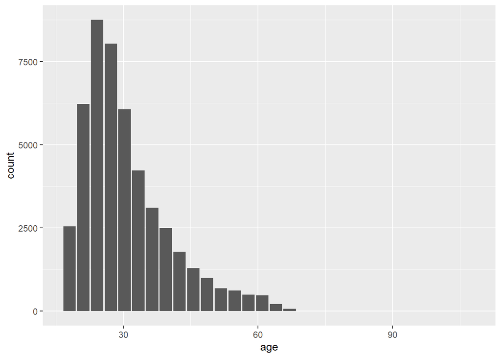

```r
dbplot_histogram(okc_train, age)
```

A common EDA exercise is to look at the relationships between the response and the individual predictors. Often, you might have prior business knowledge of what these relationships should be, so this can serve as a data quality check.

```r
prop_data <- okc_train %>%
  mutate(religion = regexp_extract(religion, "^\\\\w+", 0)) %>%
  group_by(religion, not_working) %>%
  tally() %>%
  group_by(religion) %>%
  summarize(
    count = sum(n),
    prop = sum(not_working * n) / sum(n)
  ) %>%
  mutate(se = sqrt(prop * (1 - prop) / count)) %>%
  collect()
prop_data
```

```
## # A tibble: 10 x 4
##    religion     count   prop      se
##    <chr>        <dbl>  <dbl>   <dbl>
##  1 judaism       2460 0.0793 0.00548
##  2 atheism       5615 0.117  0.00424
##  3 christianity  4688 0.117  0.00469
##  4 hinduism       361 0.0942 0.0154
##  5 islam          114 0.184  0.0363
##  6 agnosticism   7031 0.0996 0.00361
##  7 other         6247 0.0839 0.00346
##  8 <NA>         16232 0.0711 0.002
##  9 buddhism      1539 0.0897 0.00728
## 10 catholicism   3815 0.0894 0.00458
```

Note that prop_data is a small DataFrame that has been collected into memory in our R session, we can take advantage of ggplot2 to create an informative visualization:

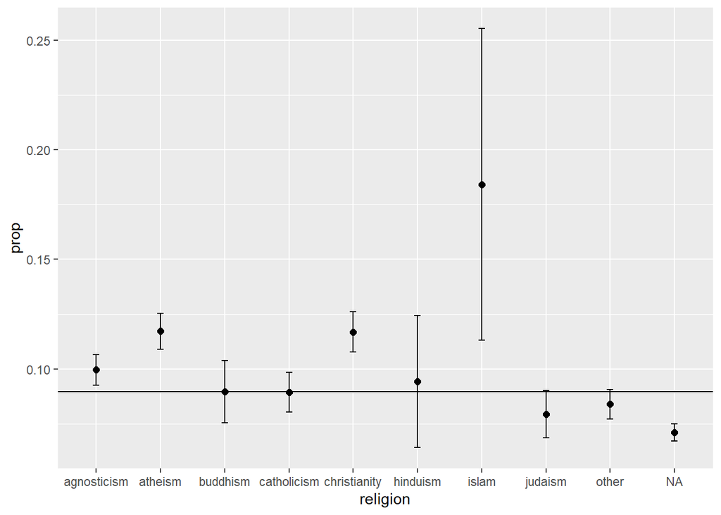

```r
prop_data %>%
  ggplot(aes(x = religion, y = prop)) + geom_point(size = 2) +
  geom_errorbar(aes(ymin = prop - 1.96 * se, ymax = prop + 1.96 * se),
                width = .1) +
  geom_hline(yintercept = sum(prop_data$prop * prop_data$count) /
                              sum(prop_data$count))
```

We take a look at the relationship between a couple of predictors: alcohol use and drug use. We would expect there to be some correlation between them. You can compute a contingency table via sdf_crosstab():

```r
contingency_tbl <- okc_train %>%
  sdf_crosstab("drinks", "drugs") %>%
  collect()

contingency_tbl
```

```
## # A tibble: 7 x 5
##   drinks_drugs missing never often sometimes
##   <chr>          <dbl> <dbl> <dbl>     <dbl>
## 1 very often        54   142    43       146
## 2 socially        8245 21023   125      4132
## 3 not at all       155  2351    16       105
## 4 desperately       74    86    23        73
## 5 often           1067  1723    64      1285
## 6 missing         1074  1233    10        66
## 7 rarely           612  3690    38       447
```

We can visualize this contingency table using a mosaic plot:

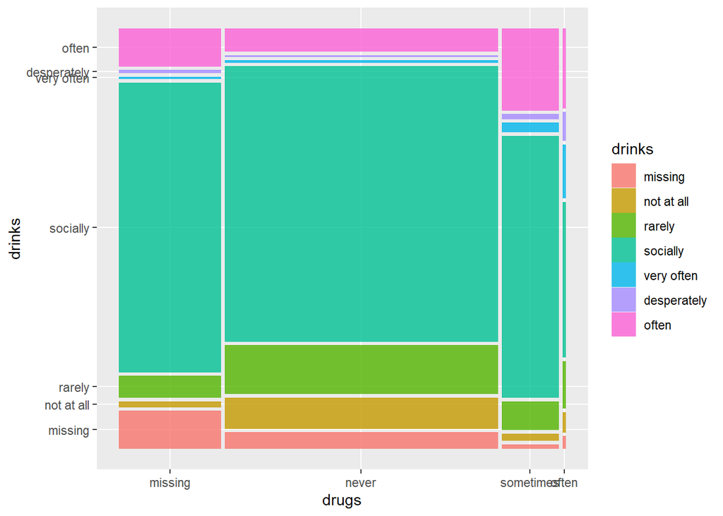

```r
library(ggmosaic)
library(forcats)
library(tidyr)

contingency_tbl %>%
  rename(drinks = drinks_drugs) %>%
  gather("drugs", "count", missing:sometimes) %>%
  mutate(
    drinks = as_factor(drinks) %>%
      fct_relevel("missing", "not at all", "rarely", "socially",
                  "very often", "desperately"),
    drugs = as_factor(drugs) %>%
      fct_relevel("missing", "never", "sometimes", "often")
  ) %>%
  ggplot() +
  geom_mosaic(aes(x = product(drinks, drugs), fill = drinks,
                  weight = count))
```

To further explore the relationship between these two variables, we can perform correspondence analysis18 using the FactoMineR package. This technique enables us to summarize the relationship between the high-dimensional factor levels by mapping each level to a point on the plane.

```r
dd_obj <- contingency_tbl %>%
  tibble::column_to_rownames(var = "drinks_drugs") %>%
  FactoMineR::CA(graph = FALSE)
```

We can then plot the results using ggplot.

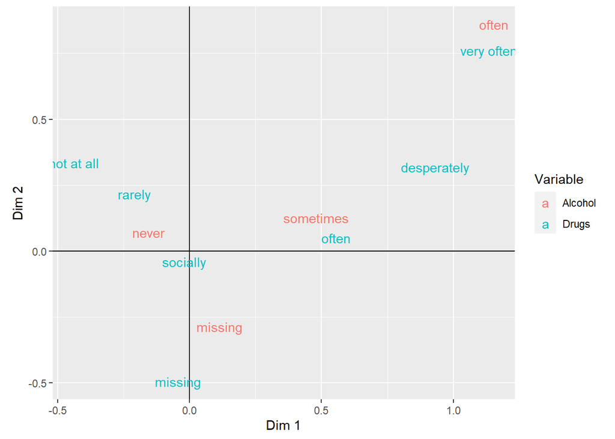

```r
dd_drugs <-
  dd_obj$row$coord %>%
  as.data.frame() %>%
  mutate(
    label = gsub("_", " ", rownames(dd_obj$row$coord)),
    Variable = "Drugs"
  )

dd_drinks <-
  dd_obj$col$coord %>%
  as.data.frame() %>%
  mutate(
    label = gsub("_", " ", rownames(dd_obj$col$coord)),
    Variable = "Alcohol"
  )

ca_coord <- rbind(dd_drugs, dd_drinks)

ggplot(ca_coord, aes(x = `Dim 1`, y = `Dim 2`,
                     col = Variable)) +
  geom_vline(xintercept = 0) +
  geom_hline(yintercept = 0) +
  geom_text(aes(label = label)) +
  coord_equal()
```

We see that the correspondence analysis procedure has transformed the factors into variables called principal coordinates, which correspond to the axes in the plot and represent how much information in the contingency table they contain. We can, for example, interpret the proximity of “drinking often” and “using drugs very often” as indicating association.

## Feature Engineering

The feature engineering exercise comprises transforming the data to increase the performance of the model. This can include things like centering and scaling numerical values and performing string manipulation to extract meaningful variables.

```r
scale_values <- okc_train %>%
  summarize(
    mean_age = mean(age),
    sd_age = sd(age)
  ) %>%
  collect()
scale_values
```

```
## # A tibble: 1 x 2
##   mean_age sd_age
##      <dbl>  <dbl>
## 1     32.3   9.44
```

We can then use these to transform the dataset:

```r
okc_train <- okc_train %>%
  mutate(scaled_age = (age - !!scale_values$mean_age) /
           !!scale_values$sd_age)
```

Since some of the profile features are multiple-select—in other words, a person can choose to associate multiple options for a variable—we need to process them before we can build meaningful models.

```r
okc_train %>%
  group_by(ethnicity) %>%
  tally()
```

```
## # Source: spark<?> [?? x 2]
##    ethnicity                                     n
##    <chr>                                     <dbl>
##  1 hispanic / latin, white                    1044
##  2 black, pacific islander, hispanic / latin     4
##  3 black, native american, indian, white         1
##  4 asian, black, pacific islander                4
##  5 black, native american, white                88
##  6 middle eastern, white, other                 33
##  7 asian, other                                 75
##  8 asian, black, white                          14
##  9 asian, hispanic / latin, white, other         9
## 10 middle eastern, pacific islander              1
## # ... with more rows
```

One way to proceed would be to treat each combination of races as a separate level, but that would lead to a very large number of levels, which becomes problematic in many algorithms. To better encode this information, we can create dummy variables for each race, as follows:

```r
ethnicities <- c("asian", "middle eastern", "black", "native american", "indian",
                 "pacific islander", "hispanic / latin", "white", "other")
ethnicity_vars <- ethnicities %>%
  purrr::map(~ expr(ifelse(like(ethnicity, !!.x), 1, 0))) %>%
  purrr::set_names(paste0("ethnicity_", gsub("\\s|/", "", ethnicities)))
okc_train <- mutate(okc_train, !!!ethnicity_vars)
okc_train %>%
  select(starts_with("ethnicity_")) %>%
  glimpse()
```

```
## Rows: ??
```

```
## Columns: 9
## Database: spark_connection
## $ ethnicity_asian           <dbl> 0, 0, NA, NA, 0, NA, 1, 0, 0, 1, 0, 0, 0, 0,~
## $ ethnicity_middleeastern   <dbl> 0, 0, NA, NA, 0, NA, 0, 0, 0, 0, 0, 0, 0, 0,~
## $ ethnicity_black           <dbl> 0, 0, NA, NA, 0, NA, 0, 0, 0, 0, 0, 0, 0, 0,~
## $ ethnicity_nativeamerican  <dbl> 0, 0, NA, NA, 0, NA, 0, 0, 0, 0, 0, 0, 0, 0,~
## $ ethnicity_indian          <dbl> 0, 1, NA, NA, 0, NA, 0, 0, 0, 0, 0, 0, 0, 0,~
## $ ethnicity_pacificislander <dbl> 0, 0, NA, NA, 0, NA, 0, 0, 0, 0, 0, 0, 0, 0,~
## $ ethnicity_hispaniclatin   <dbl> 1, 0, NA, NA, 0, NA, 0, 0, 0, 0, 1, 0, 0, 0,~
## $ ethnicity_white           <dbl> 0, 0, NA, NA, 0, NA, 0, 1, 0, 0, 0, 1, 0, 1,~
## $ ethnicity_other           <dbl> 0, 0, NA, NA, 0, NA, 0, 0, 0, 0, 0, 0, 0, 0,~
```

For the free text fields, a straightforward way to extract features is counting the total number of characters. We will store the train dataset in Spark’s memory with compute() to speed up computation.

```r
okc_train <- okc_train %>%
  mutate(
    essay_length = char_length(paste(!!!syms(paste0("essay", 0:9))))
  ) %>% compute()
```

So let’s save it first as a Parquet file—an efficient file format ideal for numeric data:

```r
#spark_write_parquet(okc_train, "data/okc-train.parquet")
```

# Supervised Learning

We need to come up with a plan to tune and validate the “candidate” models—in modeling projects, we often try different types of models and ways to fit them to see which ones perform the best. Since we are dealing with a binary classification problem, the metrics we can use include accuracy, precision, sensitivity, and area under the receiver operating characteristic curve (ROC AUC).

It is important that we don’t peek at the testing holdout set until the very end, because any information we obtain could influence our modeling decisions, which would in turn make our estimates of model performance less credible.

Using the sdf_random_split() function, we can create a list of subsets from our okc_train table:

```r
vfolds <- sdf_random_split(
  okc_train,
  weights = purrr::set_names(rep(0.1, 10), paste0("fold", 1:10)),
  seed = 42
)
```

We then create our first analysis/assessment split as follows:

```r
analysis_set <- do.call(rbind, vfolds[2:10])
assessment_set <- vfolds[[1]]
```

One item we need to carefully treat here is the scaling of variables. We need to make sure that we do not leak any information from the assessment set to the analysis set, so we calculate the mean and standard deviation on the analysis set only and apply the same transformation to both sets. Here is how we would handle this for the age variable:

```r
make_scale_age <- function(analysis_data) {
  scale_values <- analysis_data %>%
    summarize(
      mean_age = mean(age),
      sd_age = sd(age)
    ) %>%
    collect()

  function(data) {
    data %>%
      mutate(scaled_age = (age - !!scale_values$mean_age) / !!scale_values$sd_age)
  }
}

scale_age <- make_scale_age(analysis_set)
train_set <- scale_age(analysis_set)
validation_set <- scale_age(assessment_set)
```

Logistic regression is often a reasonable starting point for binary classification problems, so let’s give it a try.

```r
lr <- ml_logistic_regression(
  analysis_set, not_working ~ scaled_age + sex + drinks + drugs + essay_length
)
lr
```

```
## Formula: not_working ~ scaled_age + sex + drinks + drugs + essay_length
##
## Coefficients:
##       (Intercept)        scaled_age             sex_m   drinks_socially
##     -2.538128e+00     -1.316446e+00     -2.062960e-01      3.238017e-02
##     drinks_rarely      drinks_often drinks_not at all    drinks_missing
##      4.640313e-01     -2.156428e-01      6.632146e-01     -6.864538e-01
## drinks_very often       drugs_never     drugs_missing   drugs_sometimes
##     -1.146424e-01     -2.582205e-01     -4.727532e-01     -1.272307e-01
##      essay_length
##      3.257724e-05
```

To obtain a summary of performance metrics on the assessment set, we can use the ml_evaluate() function:

```r
validation_summary <- ml_evaluate(lr, assessment_set)
validation_summary
```

```
## BinaryLogisticRegressionSummaryImpl
##  Access the following via `$` or `ml_summary()`.
##  - features_col()
##  - label_col()
##  - predictions()
##  - probability_col()
##  - area_under_roc()
##  - f_measure_by_threshold()
##  - pr()
##  - precision_by_threshold()
##  - recall_by_threshold()
##  - roc()
##  - prediction_col()
##  - accuracy()
##  - f_measure_by_label()
##  - false_positive_rate_by_label()
##  - labels()
##  - precision_by_label()
##  - recall_by_label()
##  - true_positive_rate_by_label()
##  - weighted_f_measure()
##  - weighted_false_positive_rate()
##  - weighted_precision()
##  - weighted_recall()
##  - weighted_true_positive_rate()
```

We can plot the ROC curve by collecting the output of validation_summary$roc() and using ggplot2:

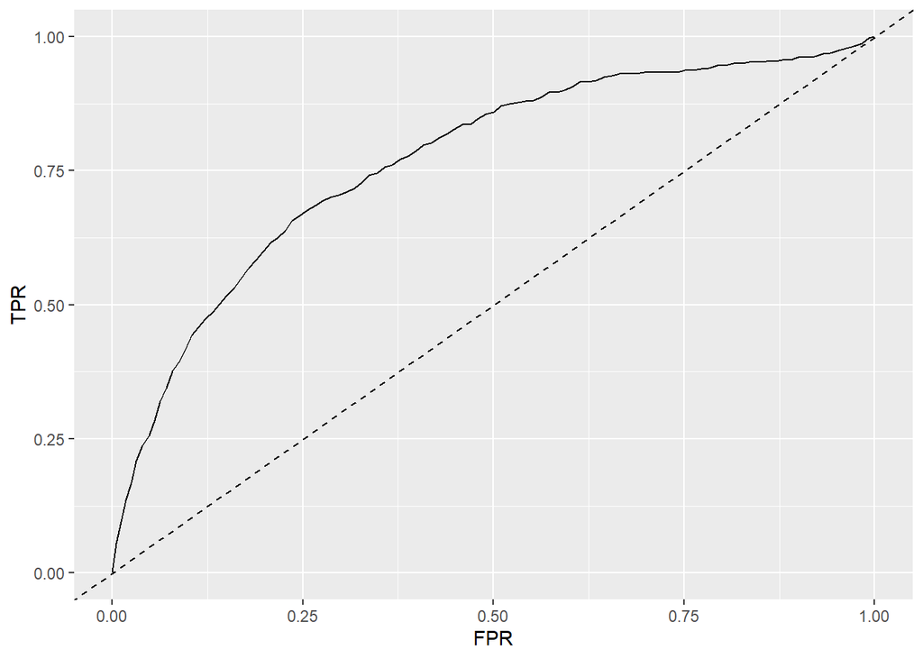

```r
roc <- validation_summary$roc() %>%
  collect()

ggplot(roc, aes(x = FPR, y = TPR)) +
  geom_line() + geom_abline(lty = "dashed")
```

The AUC is a summary measure for determining the quality of a model, and we can compute it by calling the area_under_roc() function.

```r
validation_summary$area_under_roc()
```

```
## [1] 0.7687451
```

Spark provides evaluation methods for only generalized linear models (including linear models and logistic regression). For other algorithms, you can use the evaluator functions (e.g., ml_binary_classification_evaluator() on the prediction DataFrame) or compute your own metrics.

```r
cv_results <- purrr::map_df(1:10, function(v) {
  analysis_set <- do.call(rbind, vfolds[setdiff(1:10, v)]) %>% compute()
  assessment_set <- vfolds[[v]]

  scale_age <- make_scale_age(analysis_set)
  train_set <- scale_age(analysis_set)
  validation_set <- scale_age(assessment_set)

  model <- ml_logistic_regression(
    analysis_set, not_working ~ scaled_age + sex + drinks + drugs + essay_length
  )
  s <- ml_evaluate(model, assessment_set)
  roc_df <- s$roc() %>%
    collect()
  auc <- s$area_under_roc()

  tibble(
    Resample = paste0("Fold", stringr::str_pad(v, width = 2, pad = "0")),
    roc_df = list(roc_df),
    auc = auc
  )
})
```

[output not shown]

This gives us 10 ROC curves:

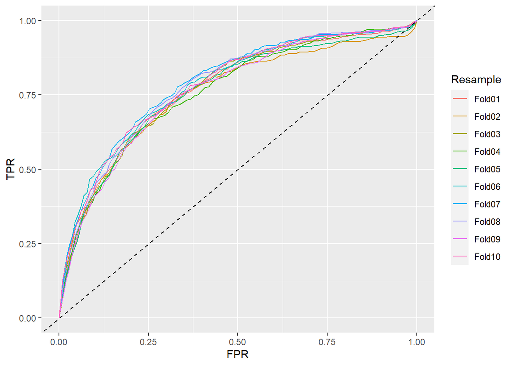

```r
unnest(cv_results, roc_df) %>%
  ggplot(aes(x = FPR, y = TPR, color = Resample)) +
  geom_line() + geom_abline(lty = "dashed")
```

```r
mean(cv_results$auc)
```

```
## [1] 0.7711609
```

### Generalized Linear Regression

If you are interested in generalized linear model (GLM) diagnostics,you can also fit a logistic regression via the generalized linear regression interface by specifying family = “binomial”. Because the result is a regression model, the ml_predict() method does not give class probabilities. However, it includes confidence intervals for coefficient estimates:

```r
glr <- ml_generalized_linear_regression(
  analysis_set,
  not_working ~ scaled_age + sex + drinks + drugs,
  family = "binomial"
)

tidy_glr <- tidy(glr)
```

We can extract the coefficient estimates into a tidy DataFrame, which we can then process further—for example, to create a coefficient plot, which you can see in Figure 4.9.

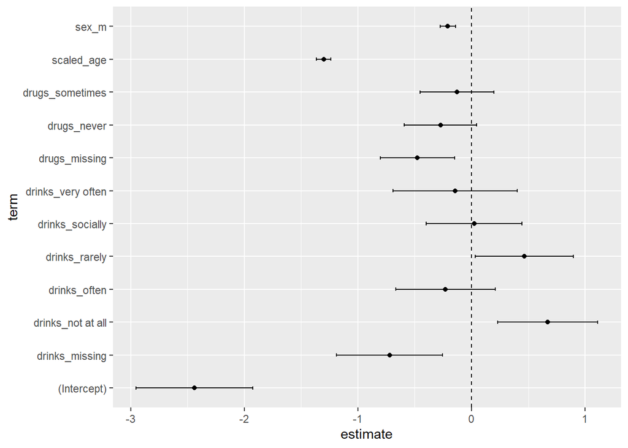

```r
tidy_glr %>%
  ggplot(aes(x = term, y = estimate)) +
  geom_point() +
  geom_errorbar(
    aes(ymin = estimate - 1.96 * std.error,
       ymax = estimate + 1.96 * std.error, width = .1)
  ) +
  coord_flip() +
  geom_hline(yintercept = 0, linetype = "dashed")
```

### Other Models

Spark supports many of the standard modeling algorithms and it’s easy to apply these models and hyperparameters (values that control the model-fitting process) for your particular problem. You can find a list of supported ML-related functions in the appendix. The interfaces to access these functionalities are largely identical, so it is easy to experiment with them. For example, to fit a neural network model we can run the following:

```r
nn <- ml_multilayer_perceptron_classifier(
  analysis_set,
  not_working ~ scaled_age + sex + drinks + drugs + essay_length,
  layers = c(12, 64, 64, 2)
)
```

This gives us a feedforward neural network model with two hidden layers of 64 nodes each. Note that you have to specify the correct values for the input and output layers in the layers argument. We can obtain predictions on a validation set using ml_predict():

```r
predictions <- ml_predict(nn, assessment_set)
```

Then, we can compute the AUC via ml_binary_classification_evaluator():

```r
ml_binary_classification_evaluator(predictions)
```

```
## [1] 0.7515056
```

## Unsupervised learning

In this section, we show how to perform a basic topic-modeling task on the essay data in the OKCupid dataset. Our plan is to concatenate the essay fields (of which there are 10) of each profile and regard each profile as a document, then attempt to discover topics (we define these soon) using Latent Dirichlet Allocation (LDA).

### Data preparation

Before analyzing a dataset (or a subset of one), we want to take a quick look at it to orient ourselves.

```r
essay_cols <- paste0("essay", 0:9)
essays <- okc %>%
  select(!!essay_cols)
essays %>%
  glimpse()
```

```
## Rows: ??
```

```
## Columns: 10
## Database: spark_connection
## $ essay0 <chr> "about me:<br />\n<br />\ni would love to think that i was some~
## $ essay1 <chr> "currently working as an international agent for a freight\nfor~
## $ essay2 <chr> "making people laugh.<br />\nranting about a good salting.<br /~
## $ essay3 <chr> "the way i look. i am a six foot half asian, half caucasian mut~
## $ essay4 <chr> "books:<br />\nabsurdistan, the republic, of mice and men (only~
## $ essay5 <chr> "food.<br />\nwater.<br />\ncell phone.<br />\nshelter.", "deli~
## $ essay6 <chr> "duality and humorous things", NA, NA, "cats and german philoso~
## $ essay7 <chr> "trying to find someone to hang out with. i am down for anythin~
## $ essay8 <chr> "i am new to california and looking for someone to wisper my se~
## $ essay9 <chr> "you want to be swept off your feet!<br />\nyou are tired of th~
```

The HTML tags and special characters pollute the data since they are not directly input by the user and do not provide interesting information. Similarly, since we have encoded missing character fields with the missing string, we need to remove it.

```r
essays <- essays %>%
  # Replace `missing` with empty string.
  mutate_all(list(~ ifelse(. == "missing", "", .))) %>%
  # Concatenate the columns.
  mutate(essay = paste(!!!syms(essay_cols))) %>%
  # Remove miscellaneous characters and HTML tags
  mutate(words = regexp_replace(essay, "\\n|&nbsp;|<[^>]*>|[^A-Za-z|']", " "))
```

Note here we are using regex_replace(), which is a Spark SQL function.